# Barrow Data

rza

# Description

```
This script was written to read in data that was originally downloaded using a telnet protocol and saved as .dat files.
Data files are accumulated in two folders, one for each circuit board.
The data originate from an experimental soil warming experiment in Barrow, Alaska.
```

# Code

## Install required packages

These packages only need to be installed once, then this code can be commented out or deleted. Often, knitr does not like to install from the command window. If this is the case, look to the bottom right window and click on Packages -> Install -> and search for `knitr` in the window that opens.

Knitr will provide a row of buttons across the top of the top left window in RStudio which allow you to view this document in html format (by clicking on the “Knit HTML” button), as well as run some or all of the code chunks below (by clicking on the “Chunks” button)

```r
#ptm <- proc.time() #start timer
#uncomment to install packages from command line
#install.packages("knitr")
#install.packages("reshape")
```

## Enter path

```r
##enter path to the two folders that contain data from each circuit board
path = "/Users/rzabramoff/Dropbox (Climate)/NGEE/MicroWarming Data/Data July 29-Aug 1 2015 copy"
path2 = "/Users/rzabramoff/Dropbox (Climate)/NGEE/MicroWarming Data/Data July 29-Aug 1 2015 copy_number 2 copy ROSE EDIT/"
```

## Read in files, cut non-data rows, and parse

```r
  readMerge <- function(path) {
        files <- list.files(path, full.names=TRUE) #list files in folder

          for(i in 1: length(files)) {
            data <- read.table(files[i], header = FALSE, sep="\t", quote = "") #load files
            cols <- as.character(data[,1]) #default data type is factor, change to character (i.e., string) to manipulate in next line
            data <- as.data.frame(data[grep("^<\\|.*\\|>$", cols),]) #select only rows that satisfy the condition: "<|" at SOL & "|>" at EOL
            # if the merged dataset does exist, append to it
            if (exists("dataset")){
              temp_dataset <- data
              dataset<-rbind(dataset, temp_dataset)
              rm(temp_dataset)
            }
            # if the merged dataset doesn't exist, create it
            if (!exists("dataset")){
              dataset <- data
            }
          }

        #remove whitespace from data strings
        whitespace <- function(x) {
          ch <- gsub(" ", "", x)
        }
        ch <- lapply(dataset, whitespace)

        ##split strings at | to assign columns
        newdata <- data.frame(matrix(0, nrow = nrow(dataset) , ncol = as.numeric(37))) #create empty matrix
        parsefx <- function(ch) {
          x <- strsplit(ch, "\\|")
          newdata <- do.call(rbind, lapply(x, `[`, c(1L:37L)))
        }
        newdata <- as.data.frame(lapply(ch, parsefx))
    return(newdata)
  }

  data <- readMerge(path)
  data2 <- readMerge(path2)
```

## Enter column headers

There are two data sheets, one for each folder.  
path -> data  
path2 -> data2

```r
  #headers for control board
   colnames(data) <- c("start", "date", "time", "id", "log", "BoardTemp", "U.R.8.5", "U.R.8.10", "U.R.8.15", "U.R.8.20", "U.R.8.25", "H.R.8.5", "H.R.8.10", "H.R.8.15", "H.R.8.20", "H.R.8.25", "H.M.6.5", "H.M.6.10", "H.M.6.20", "H.M.6.35", "H.M.6.50", "NotKnown1", "UAvg", "HAvg", "TempDiff", "HeaterSetting", "NotKnown2", "Voltage", "HeaterIntervalCount", "NotKnown3", "end")
  #headers for monitoring board
       colnames(data2) <- c("start", "date", "time", "id", "log", "BoardTemp", "H.M.10.5", "H.M.10.10", "H.M.10.20", "H.M.10.35", "H.M.10.50", "U.M.6.5", "U.M.6.10", "U.M.6.20", "U.M.6.35", "U.M.6.50", "U.M.10.5", "U.M.10.10", "U.M.10.20", "U.M.10.35", "U.M.10.50", "NotKnown1", "UAvg", "HAvg", "TempDiff", "HeaterSetting", "NotKnown2", "Voltage", "HeaterIntervalCount", "NotKnown3", "end")
```

## Organize data in wide format

There are two data files, one for each folder.  
path -> wide  
path2 -> wide2

```r
  #redefine column types
        redefCol <- function(data) {
          convert.magic <- function(obj,types){
            wide <- lapply(1:length(obj),FUN = function(i){FUN1 <- switch(types[i],character = as.character,numeric = as.numeric, factor = as.factor); FUN1(obj[,i])})
            names(wide) <- colnames(obj)
            as.data.frame(wide,stringsAsFactors = FALSE)
          }

          widech <- convert.magic(data, c('character', 'factor', 'character', 'factor', 'factor', rep('character', 32)))
          wide <- convert.magic(widech, c('character', 'factor', 'character', 'factor', 'factor', rep('numeric', 32)))
          wide$date <- as.Date(wide$date, "%d-%m-%Y")
          wide$time <- with(widech, as.POSIXct(paste(date,time), format= "%d-%m-%Y %H:%M:%S")) #time zone is still PDT (change time zone signature <- Alaska)
          wide <- subset(wide, select = -c(start, end, NA., NA..1, NA..2, NA..3, NA..4, NA..5))
          return(wide)
        }

        wide <- redefCol(data)
        wide2 <- redefCol(data2)
```

## Melt to long format and concatenate into one data object

The data object created by this chunk is called `long`.  
Some helpful commands:  
`head(long)` <- view first 6 lines  
`str(long)` <- view the structure of the data object  
`nrow(long)` <- query the number of rows in this data object  
`summary(long)` <- view some automatically-generated summary data  
`long[1,1]` <- to view the element in the row 1, column 1  
`long[long$depth == 1,]` <- select all of the rows that meet the condition depth = 1  
At any time you can assign one of these commands to a variable. For example, to create a new data object that contains only data where depth = 1  
`newdata <- long[long$depth == 1,]`  
Check the ranges of this variable to be sure:  
`range(long$depth)`  
`range(newdata$depth)`

```r
  #change from wide data format to long   #add 1 for first folder
  library(reshape)
  long1 <- melt(wide, id = c("date", "time", "id", "log", "BoardTemp", "NotKnown1", "UAvg", "HAvg", "TempDiff", "HeaterSetting", "NotKnown2", "Voltage", "HeaterIntervalCount", "NotKnown3"))
  long2 <- melt(wide2, id = c("date", "time", "id", "log", "BoardTemp", "NotKnown1", "UAvg", "HAvg", "TempDiff", "HeaterSetting", "NotKnown2", "Voltage", "HeaterIntervalCount", "NotKnown3"))
  long <- rbind(long1, long2)

  #split header into three columns
  test <- strsplit(as.character(long$variable), "\\.")

  long$heatStat <- unlist(lapply(test, '[[', 1)) #set header for heated or unheated status
  long$regStat <- unlist(lapply(test, '[[', 2)) #set header for regulator or monitor
  long$dist <- unlist(lapply(test, '[[', 3)) #set header for distance to center
  long$depth <- unlist(lapply(test, '[[', 4)) #set header for depth
  long <- subset(long, select = -c(variable))
```

## Optional

### Write data object to .csv or sort data

```r
  #uncomment to write data to a csv file, change path to desired destination
  #write.csv(long, file = "/Users/rzabramoff/Desktop/myfile.csv") #change file path
  #write.csv(wide, file = "/Users/rzabramoff/Desktop/myfirstwidefile.csv")
  #write.csv(wide2, file = "/Users/rzabramoff/Desktop/mysecondwidefile.csv")

  #uncomment to sort data
  #sorted1 <- long[order(long$value),] #sort by value
  #sorted2 <- long[order(long$value, long$depth),] #sort by value and depth
  #sorted3 <- long[order(long$value, rev(long$depth)),] #sort by value (ascending) and depth (descending)
```

## Plots

The code for these plots includes a lot of features that are not necessary now but may be useful, such as:  
Spatial formatting of multiple plots (`par(mfrow)`)  
Formatting for time axes (`axis.POSIXct`)  
Legends Title (`main`) Point size (`cex`)  
Point or line color (`col`)  
Point type (`pch`)  
Inserting symbols into axes (`expression`)

I can use other conditional arguments such as “|” for “or” and “!=” for “not”.

### Practice Plots

```r
#   par(mfrow = c(1,1)) #one plot in plot window
#
#   #sample plot with long data format (only plotting every 100th value for speed)
#   plot(long$time[seq(1,length(long$time), 100)], long$value[seq(1,length(long$time), 100)], ylab = expression("Temperature (" ~ degree*C ~ ")"), xlab = "Time", main = "All data", ylim = c(0,20))
#   #r <- range(long$time, na.rm = F)
#   #axis.POSIXct(1, at = seq(r[1], r[2], by = "days"), format = "%m/%d - %I%p")
#
#   #sample plot with long data format (only plotting circuit H, location 1, depths 1 & 2)
#   plot(long[long$regStat == "R",]$time, long[long$regStat == "R",]$UAvg, ylab = expression("Temperature (" ~ degree*C ~ ")"), xlab = "Time", col = 1, ylim = c(0,40))
#   points(long[long$regStat == "R",]$time, long[long$regStat == "R",]$HAvg, ylab = expression("Temperature (" ~ degree*C ~ ")"), xlab = "Time", col = 2)
#   #axis.POSIXct(1, at = seq(r[1], r[2], by = "hours"), format = "%m/%d - %I%p")
#     legend("topright",c("UAvg","HAvg"),
#          pch = c(1,1),
#          col=c(1,2),cex=1.3
#   )
#
#   plot(long[long$id == "D1EF" & long$depth == 5,]$time[seq(1,length(long$time), 100)], long[long$id == "D1EF" & long$depth == 5,]$TempDiff[seq(1,length(long$time), 100)], ylab = expression("Temperature (" ~ degree*C ~ ")"), xlab = "Time", col = 1, ylim = c(-5,10))
#     #points(long[long$id == "380C" & long$depth == 5,]$time[seq(1,length(long$time), 100)], long[long$id == "380C" & long$depth == 5,]$TempDiff[seq(1,length(long$time), 100)], ylab = expression("Temperature (" ~ degree*C ~ ")"), xlab = "Time", col = 2)
#     #points(long[long$id == "B7D1" & long$depth == 5,]$time[seq(1,length(long$time), 100)], long[long$id == "B7D1" & long$depth == 5,]$TempDiff[seq(1,length(long$time), 100)], ylab = expression("Temperature (" ~ degree*C ~ ")"), xlab = "Time", col = 3)
#     points(long[long$id == "89A1" & long$depth == 5,]$time[seq(1,length(long$time), 100)], long[long$id == "89A1" & long$depth == 5,]$TempDiff[seq(1,length(long$time), 100)], ylab = expression("Temperature (" ~ degree*C ~ ")"), xlab = "Time", col = 4)
#     points(long[long$id == "97F4" & long$depth == 5,]$time[seq(1,length(long$time), 100)], long[long$id == "97F4" & long$depth == 5,]$TempDiff[seq(1,length(long$time), 100)], ylab = expression("Temperature (" ~ degree*C ~ ")"), xlab = "Time", col = 5)
#     #points(long[long$id == "7E4F" & long$depth == 5,]$time[seq(1,length(long$time), 100)], long[long$id == "7E4F" & long$depth == 5,]$TempDiff[seq(1,length(long$time), 100)], ylab = expression("Temperature (" ~ degree*C ~ ")"), xlab = "Time", col = 6)
#     points(long[long$id == "11FD" & long$depth == 5,]$time[seq(1,length(long$time), 100)], long[long$id == "11FD" & long$depth == 5,]$TempDiff[seq(1,length(long$time), 100)], ylab = expression("Temperature (" ~ degree*C ~ ")"), xlab = "Time", col = 7)
#     #points(long[long$id == "8F0A" & long$depth == 5,]$time[seq(1,length(long$time), 100)], long[long$id == "8F0A" & long$depth == 5,]$TempDiff[seq(1,length(long$time), 100)], ylab = expression("Temperature (" ~ degree*C ~ ")"), xlab = "Time", col = 8)
#       legend("topright",c("D1EF","380C", "B7D1", "89A1", "97F4", "74EF", "11FD", "8F0A"),
#          pch = rep(1,8),
#          col=1:8,cex=1.3
#   )
```

### Nice plots

#### Plot 1: Average temperature in heated and unheated blocks

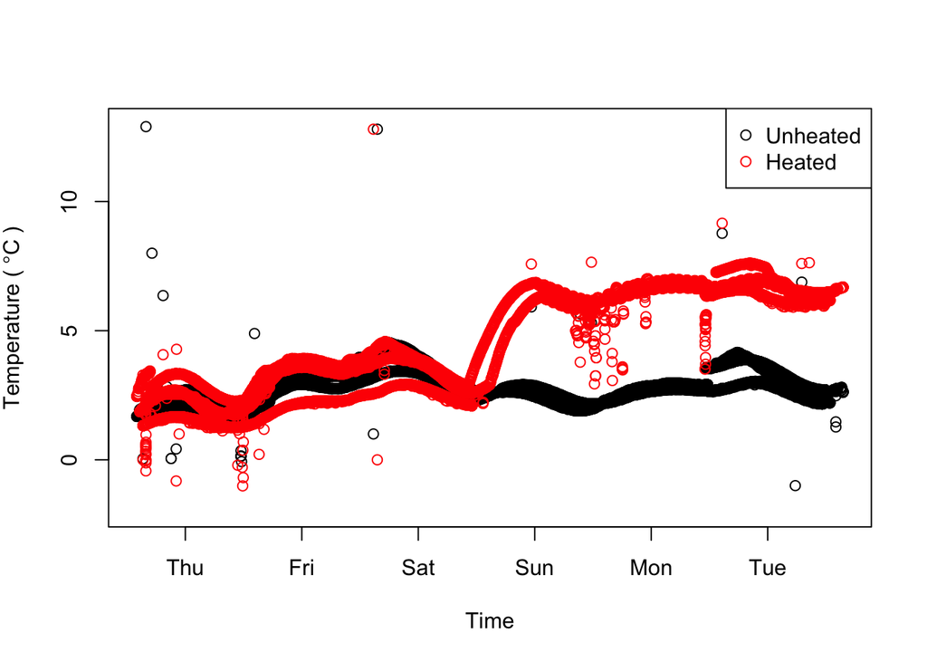

```r
    par(mfrow = c(1,1))
#Plot 1
    pointEvery = 100
      plot(long[long$id == "D1EF" | long$id == "89A1" | long$id == "97F4" | long$id == "11FD",]$time[seq(1,length(long$time), pointEvery)], long[long$id == "D1EF" | long$id == "89A1" | long$id == "97F4" | long$id == "11FD",]$UAvg[seq(1,length(long$time), pointEvery)], ylab = expression("Temperature (" ~ degree*C ~ ")"), xlab = "Time", col = 1, ylim = c(-2,13))
  points(long[long$id == "D1EF" | long$id == "89A1" | long$id == "97F4" | long$id == "11FD",]$time[seq(1,length(long$time), pointEvery)], long[long$id == "D1EF" | long$id == "89A1" | long$id == "97F4" | long$id == "11FD",]$HAvg[seq(1,length(long$time), pointEvery)], ylab = expression("Temperature (" ~ degree*C ~ ")"), xlab = "Time", col = 2)
    legend("topright",c("Unheated","Heated"),
         pch = c(1,1),
         col=c(1,2),cex=1
  )
```

#### Plot 2: Temperature difference between heated and unheated blocks

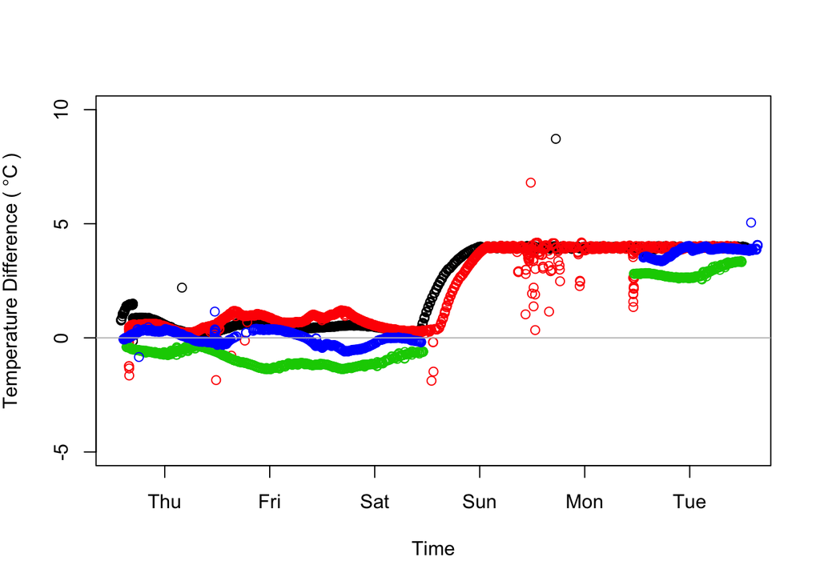

```r
#Plot 2
  pointEvery = 50
      plot(long[long$id == "D1EF" & long$depth == 5,]$time[seq(1,length(long$time), pointEvery)], long[long$id == "D1EF" & long$depth == 5,]$TempDiff[seq(1,length(long$time), pointEvery)], ylab = expression("Temperature Difference (" ~ degree*C ~ ")"), xlab = "Time", col = 1, ylim = c(-5,10))
    points(long[long$id == "89A1" & long$depth == 5,]$time[seq(1,length(long$time), pointEvery)], long[long$id == "89A1" & long$depth == 5,]$TempDiff[seq(1,length(long$time), pointEvery)], ylab = expression("Temperature Difference (" ~ degree*C ~ ")"), xlab = "Time", col = 2)
    points(long[long$id == "97F4" & long$depth == 5,]$time[seq(1,length(long$time), pointEvery)], long[long$id == "97F4" & long$depth == 5,]$TempDiff[seq(1,length(long$time), pointEvery)], ylab = expression("Temperature Difference (" ~ degree*C ~ ")"), xlab = "Time", col = 3)
    points(long[long$id == "11FD" & long$depth == 5,]$time[seq(1,length(long$time), pointEvery)], long[long$id == "11FD" & long$depth == 5,]$TempDiff[seq(1,length(long$time), pointEvery)], ylab = expression("Temperature Difference (" ~ degree*C ~ ")"), xlab = "Time", col = 4)
    abline(h = 0, col = 8)
```

```r
#Plot 2 (option 2): Temperature difference between heated and unheated blocks at all depths (equivalent plot, but fewer points skipped)
#       plot(long[long$id == "D1EF",]$time[seq(1,length(long$time), 100)], long[long$id == "D1EF",]$TempDiff[seq(1,length(long$time), 100)], ylab = expression("Temperature Difference (" ~ degree*C ~ ")"), xlab = "Time", col = 1, ylim = c(-5,10))
#     points(long[long$id == "89A1",]$time[seq(1,length(long$time), 100)], long[long$id == "89A1",]$TempDiff[seq(1,length(long$time), 100)], ylab = expression("Temperature Difference (" ~ degree*C ~ ")"), xlab = "Time", col = 2)
#     points(long[long$id == "97F4",]$time[seq(1,length(long$time), 100)], long[long$id == "97F4",]$TempDiff[seq(1,length(long$time), 100)], ylab = expression("Temperature Difference (" ~ degree*C ~ ")"), xlab = "Time", col = 3)
#     points(long[long$id == "11FD",]$time[seq(1,length(long$time), 100)], long[long$id == "11FD",]$TempDiff[seq(1,length(long$time), 100)], ylab = expression("Temperature Difference (" ~ degree*C ~ ")"), xlab = "Time", col = 4)
#     abline(h = 0, col = 8)
```

#### Plot 3: Temperature in heated and unheated block B7D1 at depth = 5cm and depth = 35cm

One block (long$id) is plotted for ease of viewing, but heating effects vary widely among different ids.  
You can type in different ids in place of B7D1 in the code below (line 256) and re-run this plot to see for yourself. On line 257, you can specify how many datapoints to skip.

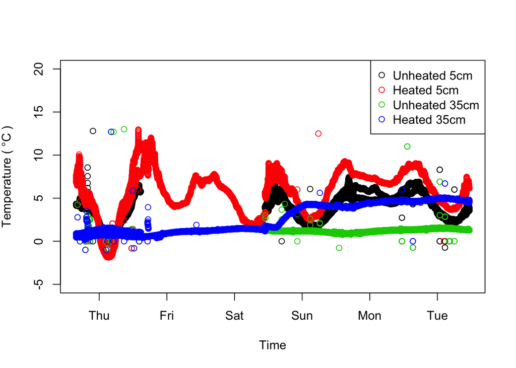

```r
# wide style test plots
#     plot(wide$time, wide$U.R.8.5, ylim = c(0,20))
#     points(wide$time, wide$U.R.8.25, col = 2)

#Plot 3
    useThisId = "B7D1"
    pointEvery = 1
    unsurf <- long[long$id == useThisId &  long$regStat == "M" & long$heatStat == "U" & long$depth == 5,]
    hotsurf <- long[long$id == useThisId & long$regStat == "M" & long$heatStat == "H" & long$depth == 5,]
    undeep <- long[long$id == useThisId & long$regStat == "M" & long$heatStat == "U" & long$depth == 35,]
    hotdeep <- long[long$id == useThisId & long$regStat == "M" & long$heatStat == "H" & long$depth == 35,]

         plot(unsurf$time[seq(1,length(long$time), pointEvery)], unsurf$value[seq(1,length(long$time), pointEvery)], ylab = expression("Temperature (" ~ degree*C ~ ")"), xlab = "Time", col = 1, ylim = c(-5,20))
  points(hotsurf$time[seq(1,length(long$time), pointEvery)], hotsurf$value[seq(1,length(long$time), pointEvery)], ylab = expression("Temperature (" ~ degree*C ~ ")"), xlab = "Time", col = 2)
  points(undeep$time[seq(1,length(long$time), pointEvery)], undeep$value[seq(1,length(long$time), pointEvery)], ylab = expression("Temperature (" ~ degree*C ~ ")"), xlab = "Time", col = 3, ylim = c(-2,13))
  points(hotdeep$time[seq(1,length(long$time), pointEvery)], hotdeep$value[seq(1,length(long$time), pointEvery)], ylab = expression("Temperature (" ~ degree*C ~ ")"), xlab = "Time", col = 4)
    legend("topright",c("Unheated 5cm","Heated 5cm", "Unheated 35cm", "Heated 35cm"),
         pch = c(1,1,1,1),
         col=c(1:4),cex=1
  )
```

```r
##This plot uses the TempDiff computed by the datalogger which is identical for different depth categories
#      plot(long[long$id == "D1EF" & long$depth == 5,]$time, long[long$id == "D1EF" & long$depth == 5,]$TempDiff, ylab = expression("Temperature Difference (" ~ degree*C ~ ")"), xlab = "Time", col = 1, ylim = c(-5,10))
#     points(long[long$id == "D1EF" & long$depth == 35,]$time, long[long$id == "D1EF" & long$depth == 35,]$TempDiff, ylab = expression("Temperature Difference (" ~ degree*C ~ ")"), xlab = "Time", col = 6)
#        legend("topright",c("5 cm","35 cm"),
#          pch = c(1,1),
#          col=c(1,6),cex=1
#   )

#proc.time() - ptm #end timer
```